# Intranet Insights

2023-01-16

## Introduzione (1)

**Obiettivo dell’analisi**

L’obiettivo del progetto è di analizzare i dati relativi alla navigazione delle pagine web di una intranet aziendale.

**Contesto**

- Nel 2018 gli Enti “X” di Pordenone e Udine si accorpano e viene costituito un unico Ente “X” con due sedi nei rispettivi capoluoghi (Pordenone e Udine), con conseguente necessità di integrare processi e *asset*, anche tecnologici.
- Tra gli *asset* tecnologici oggetto di integrazione ci sono le rispettive piattaforme per gestire la comunicazione interna e la digitalizzazione di alcuni processi:
  - Pordenone -> piattaforma *web-based* (Intranet)
  - Udine -> architettura client - server su piattaforme Lotus Domino e FileMaker.

## Introduzione (2)

L’Ente opta per avviare in processo di dismissione delle piattaforme *client-server based* in uso presso la sede di Udine effettuando il *porting* delle applicazioni sulla piattaforma web-based in uso presso la sede di Pordenone.

Il primo step di questo processo ha comportato un *refactoring* della vecchia intranet.

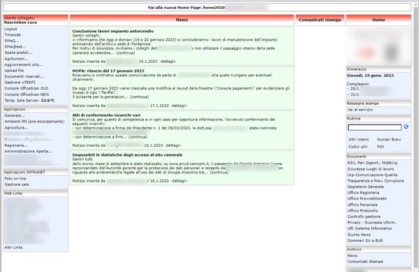

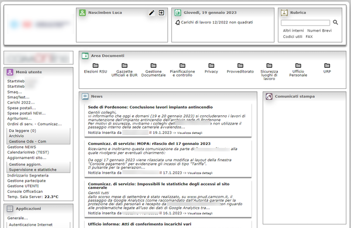

Contestualmente alle operazione di *refactoring*, è stata inserita una porzione di codice per registrare nel DataBase i **dati di navigazione degli utenti**.

## Origine e descrizione del *dataset*

Per ogni **pagina richiesta** al server vengono registrate nel DB le seguenti informazioni utilizzate per l’analisi:

- *id* - Identificativo univoco del record
- *session_id* - Session ID della [sessione PHP](https://www.php.net/manual/en/book.session.php)
- *ipaddress* - Indirizzo IP del client
- *userid* - Eventuale UserID (presente se la pagina è richieste dopo aver effettuato il login aul portale)
- *req_method* - [Metodo HTTP utilizzato](https://www.rfc-editor.org/rfc/rfc7231#section-4)
- *req_uri* - [URI della pagina richiesta](https://www.rfc-editor.org/rfc/rfc7230#section-5.3)
- *exec_time* - Tempo di esecuzione dello script, in secondi (sfruttando la [funzione PHP microtime()](https://www.php.net/manual/en/function.microtime.php))
- *user_agent* - Stringa contenente lo [user-agent](https://www.rfc-editor.org/rfc/rfc7231#section-5.5.3)
- *ux_time* - Timestamp della richiesta (ottenuta tramite la [funzione PHP time()](https://www.php.net/manual/en/function.time.php))

Dal DB viene anche mutuata parte della tabella *utenti*:

- *userid* - User ID dell’utente
- *id_sede* - Sede di assegnazione dell’utente
- *abilitato* - Booleano per lo status dell’utente

Al momento della preparazione di questa slide la tabella conta oltre 234.000 righe.  
Dopo opportune considerazioni, il dataset esaminato viene ridotto a circa 210.000 righe.

## Obiettivi dell’analisi

- **Analisi temporale e geografica**
  - *Come sono distribuite le richieste per ciascuna sede?*
  - *Com’è evoluto nel tempo il numero di richieste per ciascuna sede?*
  - *Com’è l’andamento intraday delle richieste?*
- **Analisi del tipo di browser utilizzato**
  - *Quali sono i browser utilizzati dagli utenti?*
  - *C’è differenza tra le sedi?*
- **Analisi delle applicazioni (moduli della intranet) utilizzate**
  - *Quali sono le applicazioni maggiormente utilizzate?*
- **Performance del sistema**
  - *Qual’è il tempo medio di esecuzione degli script PHP?*
  - *Da cosa è influenzato Il tempo di esecuzione degli script?*
- **Analisi dell’utilizzo della rubrica**
  - *Quali sono i termini più ricercati?*

**NB: Periodo di riferimento dal 01.05.2021 al 31.12.2022**

## Analisi temporale e geografica (1)

*Come sono distribuite le richieste per ciascuna sede?*

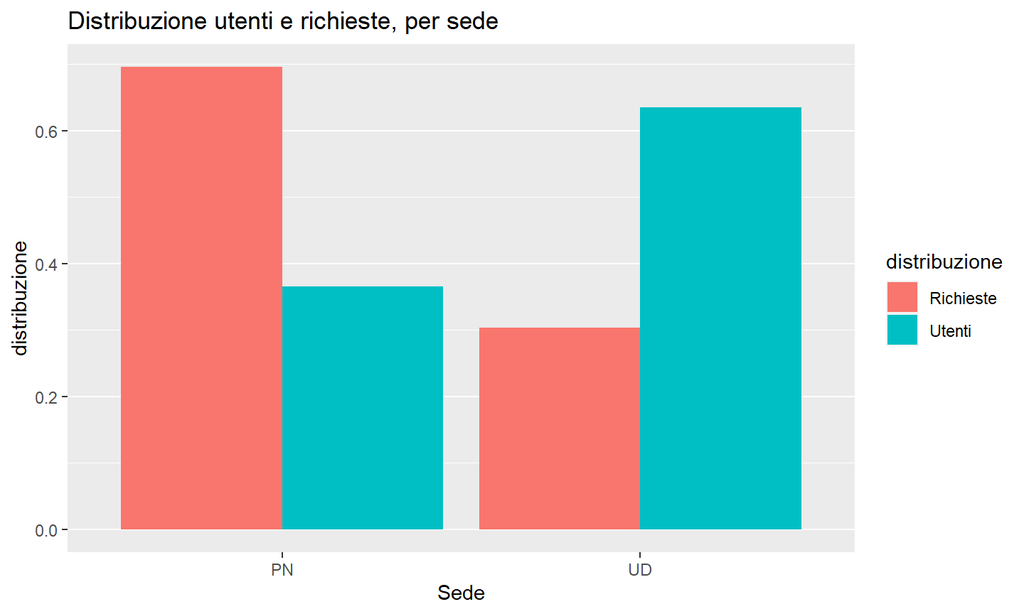

## Analisi temporale e geografica (2)

*Come sono distribuite le richieste per ciascuna sede?*

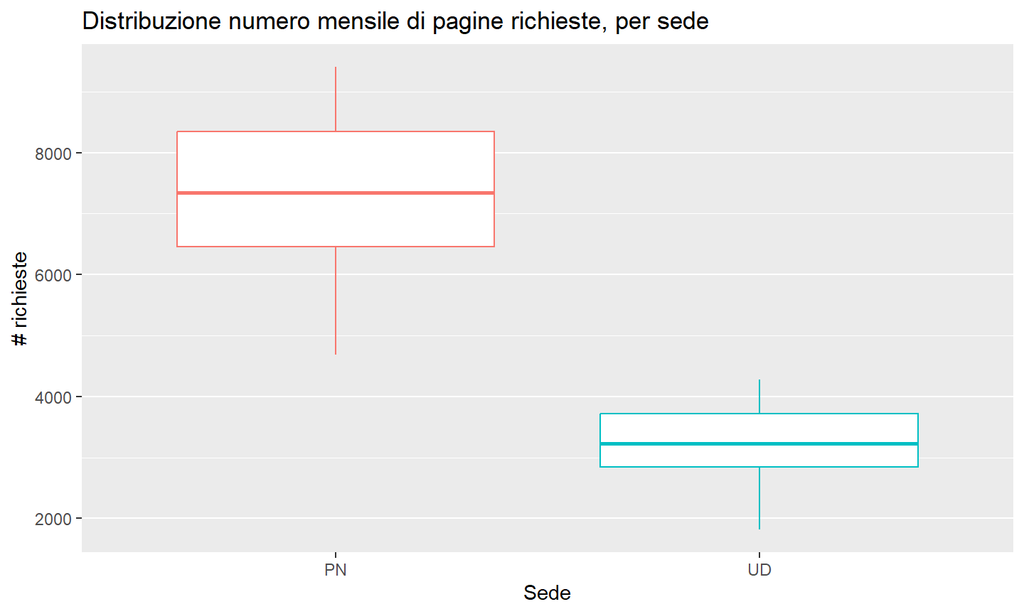

PN ~ 7.300 richieste/mese, UD ~ 3.250 richieste/mese L’andamento mensile delle richieste di Udine non ha avuto particolari picchi positivi o negativi.  
Le richieste dalla sede di Pordenone presentano invece una variabiltà maggiore.

## Analisi temporale e geografica (3)

*Come è evoluto nel tempo il numero di richieste per ciascuna sede?*

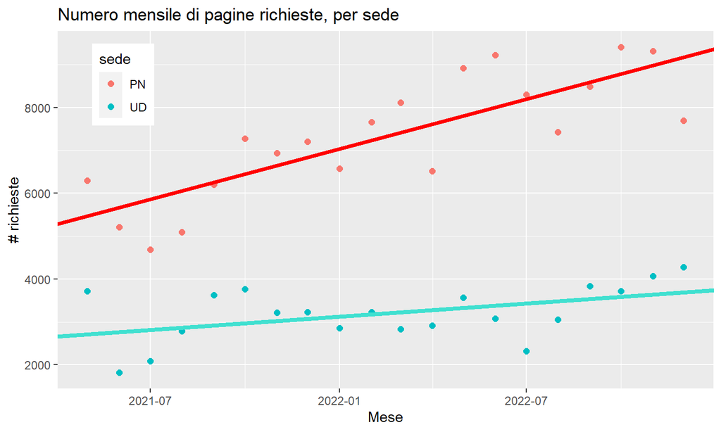

Le richieste dalla sede di Pordenone crescono più di quelle di Udine.  
Ci si attende che con il progredire del porting delle applicazioni Lotus e FileMaker, il trend per la sede di Udine migliori.

## Analisi temporale e geografica (4)

*Com’è l’andamento *intraday* delle richieste?*

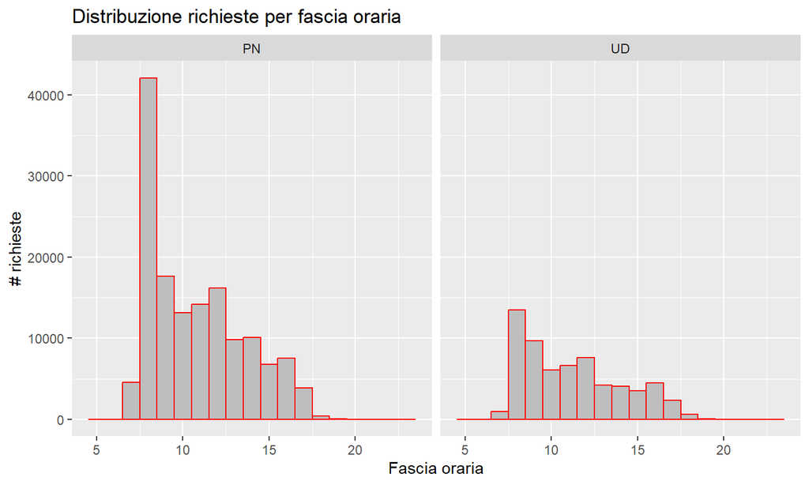

Le richieste sono concentrate nella fascia antimeridiana, con un picco nella fasce orarie 8-9 e 9-10.  
L’andamento è sovrapponibile per le due sedi.

## Analisi del tipo di browser utilizzato (1)

*Quali sono i browser utilizzati dagli utenti? C’è differenza tra le sedi?*

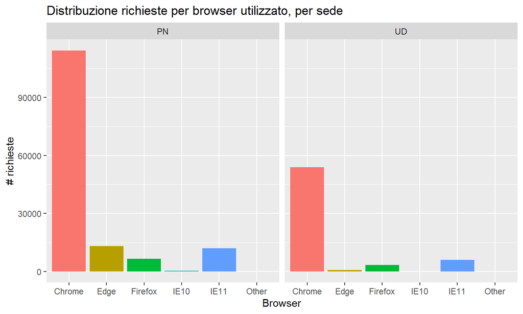

Come atteso (policy aziendale) prevale l’uso di Google Chrome, per entrambe le sedi.  
Degno di nota: per PN è presente una quota di richieste provenienti da browser Microsoft Edge  
**Da approfondire: quota di utilizzo di IE10/IE11, in End Of Life**

## Analisi del tipo di browser utilizzato (2)

*Dettaglio sull’utilizzo di Internet Explorer 10/11*

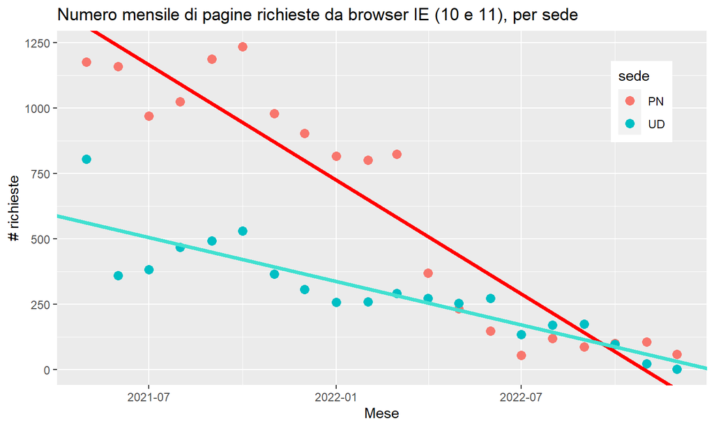

L’analisi è di conforto, perchè è evidente il progressivo abbandono del browser IE10/IE11.  
I dati rilevati a dicembre 2022 mostrano infatti un numero residuo di richieste inferiore alle 100 unità per entrambe le sedi (prossimo allo zero per la sede di Udine).

## Utilizzo applicazioni (moduli) della Intranet (1)

Attraverso il portale vengono erogati alcuni servizi:

- **Homepage**
- **Rubrica**: piccolo motore per la ricerca dei contatti aziendali
- **OdsCom**: applicazione per la distribuzone dei Ordini di Servizio / Comunicazioni
- **Documenti**: repository di documenti di interesse aziendale
- **News**: gestione e consultazione di *news* di interesse aziendale
- **UserProfile**: gestione del proprio profilo utente

## Utilizzo applicazioni (moduli) della Intranet (2)

*Quali sono le applicazioni più utilizzate?*

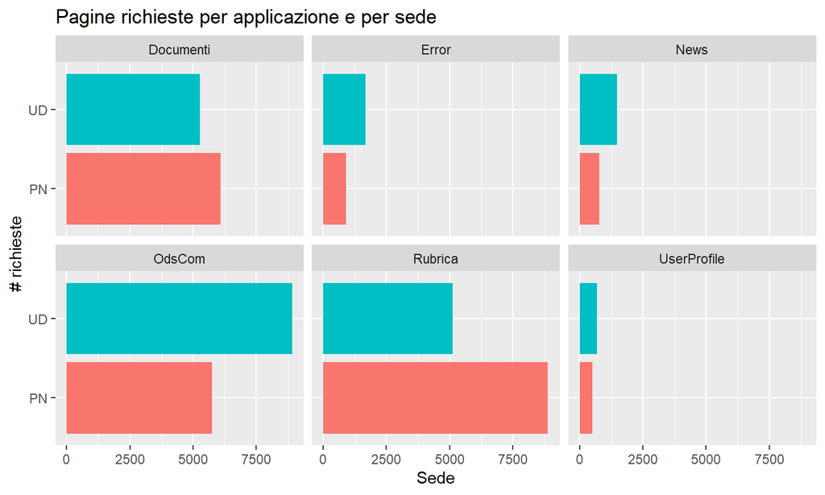

Alcuni moduli (OdsCom, UserProfile, News) sono utilizzate presso le due sedi in misura proporzionale al numero di utenti potenziali (UD > PN).  
Due applicazioni particolari (Documenti e Rubrica) sono usate prevalentemente a Pordenone.  
E’ utile quindi indagare sull’andamento storico dell’utilizzo di queste due applicazioni, per capire se ci si può attendere un’evoluzione .

## Utilizzo applicazioni (moduli) della Intranet (3)

*Dettaglio su applicazione “Documenti”*

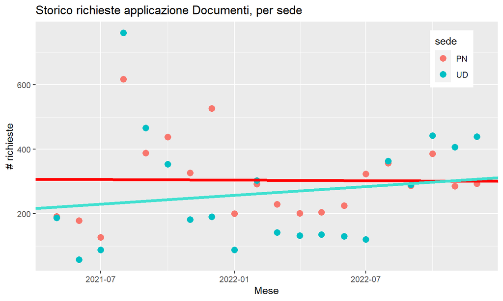

Per quanto riguarda il modulo **Documenti** non si apprezza un chiaro trend, ma l’analisi appare disturbata da alcuni picchi apparentemente anomali riscontrati tra agosto e dicembre 2021, in assenza dei quali si apprezzerebbe un trend positivo. I picchi sono probabilmente dovuti ad un *hype* generato da una prima corposa pubblicazione di documenti.

## Utilizzo applicazioni (moduli) della Intranet (4)

*Dettaglio su applicazione “Rubrica”*

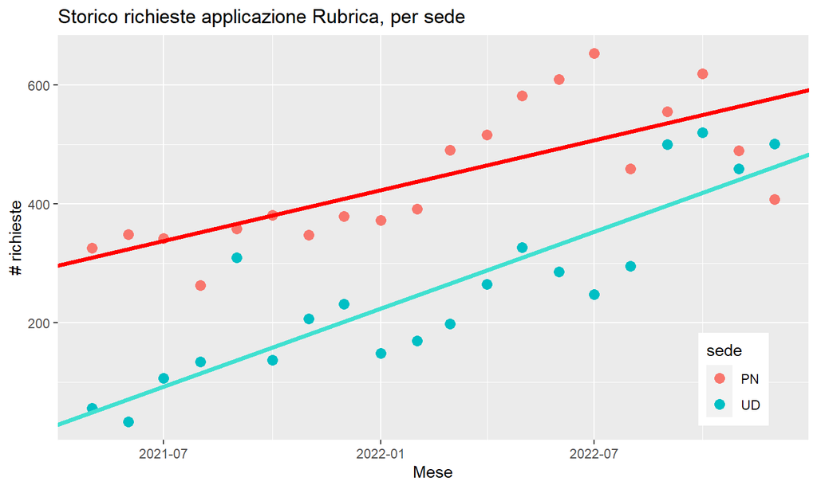

Il trend per il modulo Rubrica è invece più chiaramente individuabile: l’utilizzo della Rubrica ha avuto un costante aumento nel periodo osservato, con una *slope* più elevata per Udine, tanto che nell’ultimo periodo osservato le due sedi hanno generato un numero di richieste sovrapponibile.

## Performance del sistema (1)

*Analisi tempo di esecuzione dello script PHP*

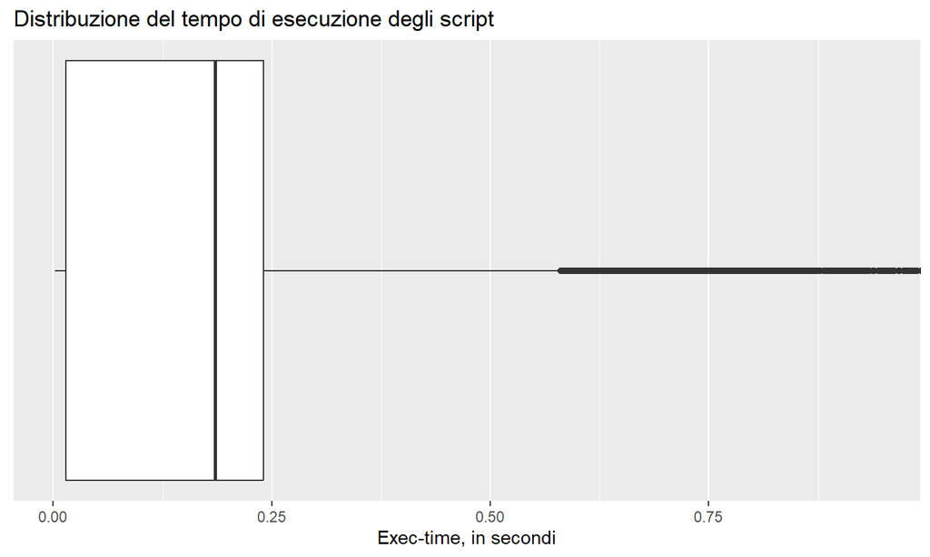

Si può notare che il tempo di esecuzione presenta una distribuzione caratterizzata da una coda lunga a destra, con una tempo di esecuzione mediano di 0.185s; sono presenti inoltre numerosi *outliers* sulla coda destra.

## Performance del sistema (2)

*L’applicazione influenza il tempo di esecuzione?*

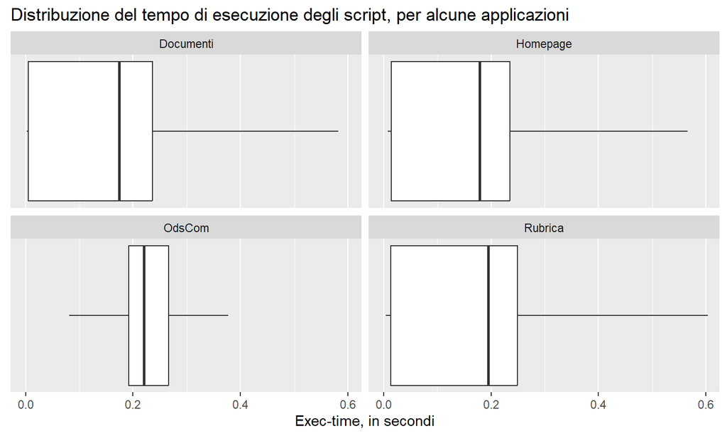

Si nota una distribuzione nettamente diversa per l’applicazione OdsCom, mentre le altre analizzate hanno un comportamento sovrapponibile a quello generale.  
Da notare che sia l’applicazione “Documenti” sia l’applicazione “OdSCom” sono caratterizzate dall’accesso al file system, particolare che avrebbe potuto influire sul tempo di esecuzione, cosa che invece non viene evidenziata dall’analisi.

## Performance del sistema (3)

*Il “Log-in status” influenza il tempo di esecuzione?*

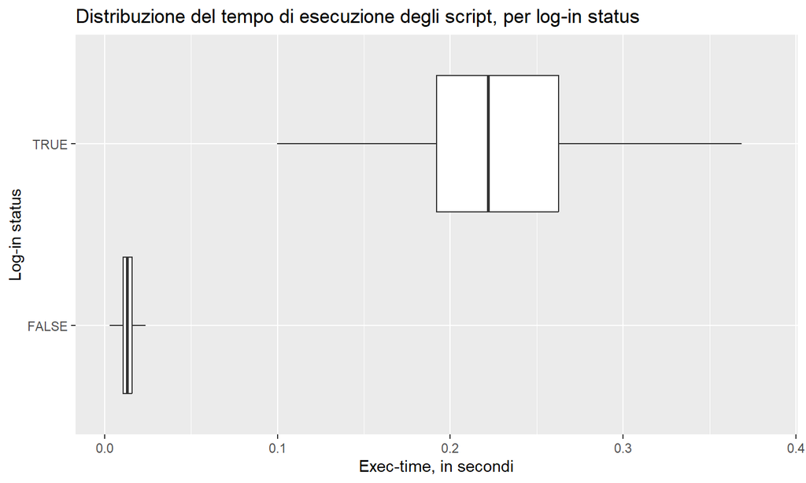

Dal grafico è evidente che il login status è determinante rispetto al tempo di esecuzione degli script.

## Performance del sistema (4)

*Il “Login status” influenza il tempo di esecuzione?*

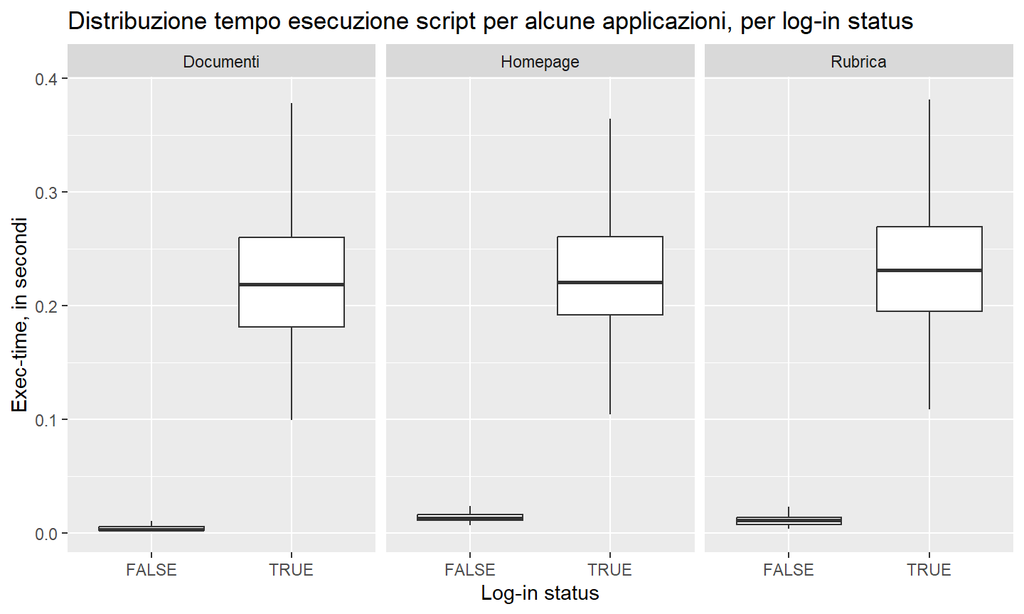

Dal boxplot risulta evidente che le richieste “logged_in” hanno un tempo di esecuzione di molte volte maggiore, anche per applicazioni il cui login non è necessario e non incide quindi sull’esecuzione dell’applicazione stessa.  
Il fattore che influisce maggiormente sul tempo di esecuzione è quindi il log-in status.

## Performance del sistema (5)

*L’orario influenza il tempo di esecuzione?*

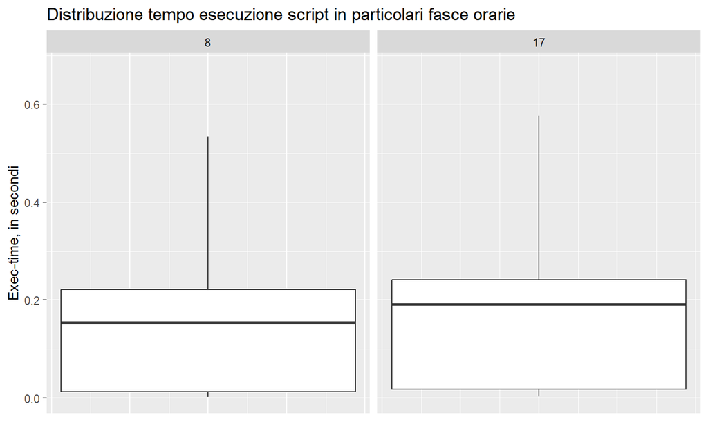

Vengono prese in esame la fascia oraria 8-9 (ora di punta) con fascia oraria 17-18 (fine giornata).  
Non si riscontrano differenze significative.  
Si conclude che l’infrastruttura appare al momento adeguatamente dimensionata al carico di lavoro in ogni fascia oraria.

## Analisi dell’utilizzo della rubrica

*Quali sono i termini più ricercati?*

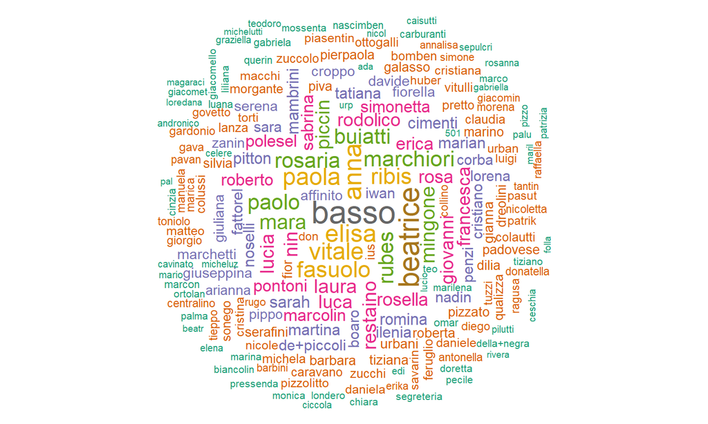

Il **wordcloud** evidenzia che viene utilizzata con netta prevalenza la modalità di ricerca “per nome persone”, mentre le ricerche “per ufficio” e “per numero” sono usate sporadicamente.

## *Grazie per l’attenzione!*